# How do we do Bayes: a really brief primer

Lets look at our chains for our parameters mu and sigma

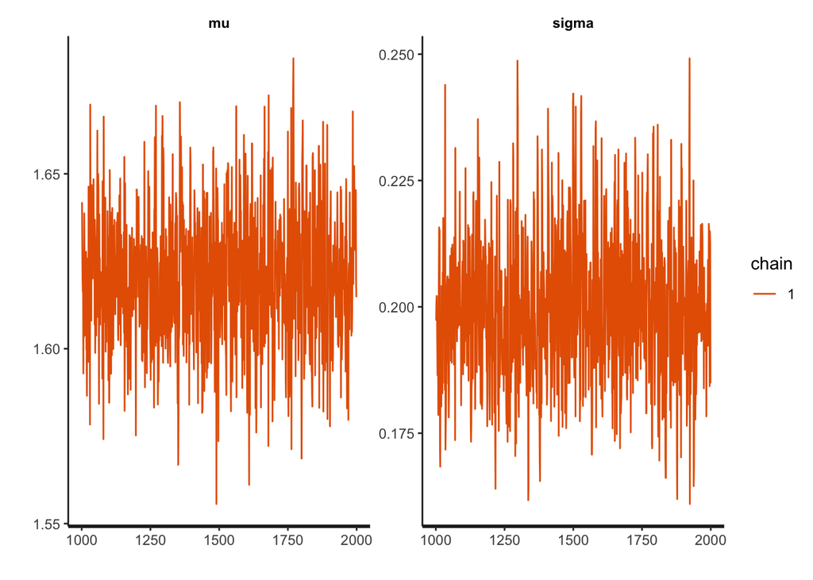

```r
traceplot(fitstan_HMC, pars = c("mu", "sigma"))
```

These plots are called trace plots. We see that the trace plots vary around some mean and don’t seem to be trending any direction. This means we have converged on a parameter estimate that makes the model probable.

We can also look at histograms of the samples.

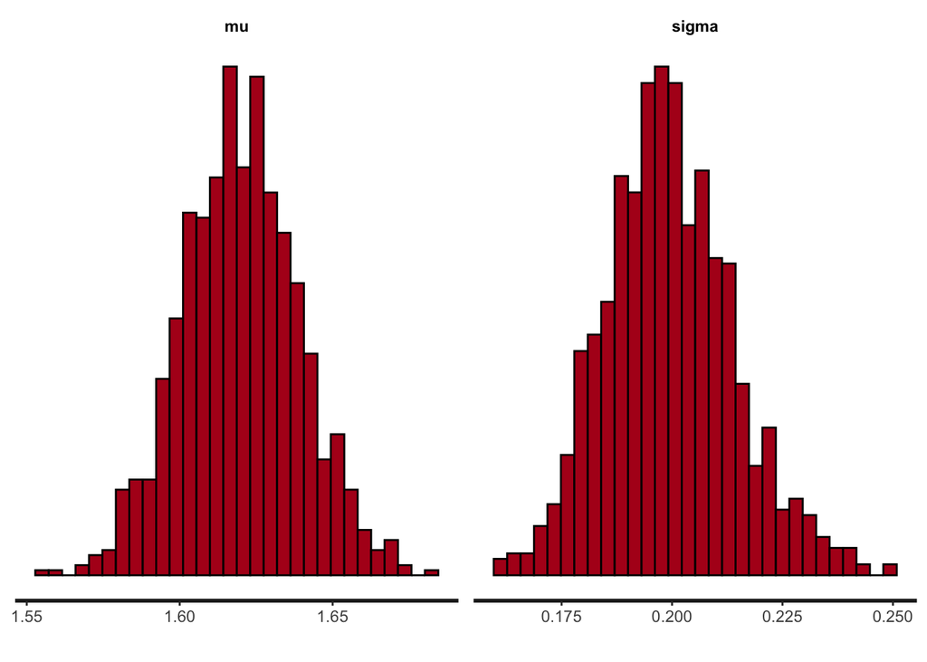

```r
stan_hist(fitstan_HMC, pars = c("mu", "sigma"))
```

We typically want to doublecheck via some simple statistics that convergence has happened. Shinystan has some great tools for this. Shinystan is an R package, see here: http://mc-stan.org/shinystan/index.html

Because shinystan is a shiny app it doesn’t work to put it in this markdown, but one would call it like this: shinystan(yourModelObject) from within R (after installing the shinystan package and loading it). We can also get a lot of info by printing the model object to the screen, like this:

```r
fitstan_HMC
```

```
## Inference for Stan model: calcMeanNoLog.
## 1 chains, each with iter=2000; warmup=1000; thin=1;
## post-warmup draws per chain=1000, total post-warmup draws=1000.
##
##         mean se_mean   sd   2.5%    25%    50%    75%  97.5% n_eff Rhat
## mu      1.62    0.00 0.02   1.58   1.61   1.62   1.63   1.66   740    1
## sigma   0.20    0.00 0.01   0.17   0.19   0.20   0.21   0.23   669    1
## lp__  109.93    0.04 1.00 107.30 109.52 110.26 110.64 110.90   540    1
##
## Samples were drawn using NUTS(diag_e) at Tue Oct 12 10:37:39 2021.
## For each parameter, n_eff is a crude measure of effective sample size,
## and Rhat is the potential scale reduction factor on split chains (at
## convergence, Rhat=1).
```

This helpful summary tells us the name of the model, info on chains, including warm up and thinning (how many samples are removed, so that samples are not too autocorrelated, see the Stan help).

Rhat is another diagnostic measure. It compares within and between chain variance (like an anova). If Rhat is way bigger than one then things are bad, because one’s chains haven’t converged on the same thing, but if rhat is near one then the chains are similar. See more here: https://mc-stan.org/rstan/reference/Rhat.html

Yay, we are done.

# Pro tips

When making a new model, simulate some data where the truth is known then run your model on it to make sure it works.

Be patient. This stuff is hard.

For models with vast numbers of parameters then one will either need to get clever regarding splitting up sampling or the model itself or consider tools like variational inference. Otherwise, Stan will take too long.

JAGS and BUGS are other tools that are analogous to Stan, but are becoming defunct because they are slower. They still work (and of course, for the masochistic one could make one’s own sampler), but if you are just starting then start with Stan.

Stan models can also be specified using a different method, using sums of logs. Like this:

```stan
data {
  int<lower = 1> N;  // Our sample size
  vector[N] y;  // Our data (a vector)
}

parameters {
  real mu;
  real<lower=0> sigma;
}

model {
  // Priors:
  target += normal_lpdf(mu | 1.7, 0.3);
  target += lognormal_lpdf(sigma | 0, 1);
  // Likelihood:
  for(i in 1:N)
    target += normal_lpdf(y[i] | mu, sigma);
}
```

The “normal_lpdf” part means we are taking the logs of the PDF. The “+=” operator means we adding each of those values to the variable called “target”. Target is a special variable used by Stan that is used to hold our posterior probability. Why are we adding up logged values? This is because multiplying logged probabilities is the same as adding the logs, but adding up a bunch of small values can be easier than multiplying tons of tiny values together (google underflow to learn more about this, basically the numbers for tiny probabilities can get so small the computer actually can’t keep track. Doing this addition of logs trick is a common workaround).

## References

https://mc-stan.org/

Unlike most software, the Stan documentation is totally fantastic.

https://xcelab.net/rm/statistical-rethinking/ Statistical rethinking by McElrith is a super good intro to this stuff. I haven’t read the whole thing, but the first few chapters are nice.

https://www.amazon.com/Doing-Bayesian-Data-Analysis-Tutorial/dp/0123814855 The Kruschke puppy book. I found this helpful when I started, but am not sure that it has aged well.